# Data Analysis with *pandas*

The United States Social Security Administration (SSA) has made available data on the frequency of baby names from 1880 through the present. Download data set [US Baby Names 1880-2023](https://www.ssa.gov/oact/babynames/names.zip) (names.zip, 7MB). Create a folder named **data** and unpack the contents of the .zip file there.

The ZIP file contains several text files (`yob1880.txt`, `yob1881.txt`, ...). Each file contains yearly data about the number of births for particular name. To safeguard privacy, the SSA restricted the list of names to those with at least 5 occurrences.

Each file contains multiple comma-separated values. Here are the first five rows of `yob1880.txt`:

```
Mary,F,7065
Anna,F,2604
Emma,F,2003
Elizabeth,F,1939
Minnie,F,1746
```

We will try to answer several questions such as:

- How many boys/girls were born each year?
- Which was the most popular boy/girl name each particular year?
- ...

```python
import pandas as pd
import numpy as np
import matplotlib.pyplot as plt
```

```python
# show matplotlib graphics inline
%matplotlib inline
plt.rc('figure', figsize=(18, 3))
plt.rcParams['figure.facecolor'] = 'w'
```

```python
# set the maximum number of rows to be displayed
pd.options.display.max_rows = 10
```

```python
pd.__version__
```

```
'2.2.2'
```

### The DataFrame Data Structure

The main pandas data structure is the [DataFrame](http://pandas.pydata.org/pandas-docs/stable/reference/api/pandas.DataFrame.html), which you can think of as representing a table or spreadsheet of data.

We will first read the file "yob1880.txt" into a DataFrame. We will then obtain some basic information about the data.

```python
# read one of the files and set header
names = pd.read_csv('data/yob1880.txt', names=['name', 'sex', 'births'])
```

```python
names
```

|  | name | sex | births |
| --- | --- | --- | --- |
| 0 | Mary | F | 7065 |
| 1 | Anna | F | 2604 |
| 2 | Emma | F | 2003 |
| 3 | Elizabeth | F | 1939 |
| 4 | Minnie | F | 1746 |
| ... | ... | ... | ... |
| 1995 | Woodie | M | 5 |
| 1996 | Worthy | M | 5 |
| 1997 | Wright | M | 5 |
| 1998 | York | M | 5 |
| 1999 | Zachariah | M | 5 |

2000 rows × 3 columns

```python
names.info()
```

```
<class 'pandas.core.frame.DataFrame'>
RangeIndex: 2000 entries, 0 to 1999
Data columns (total 3 columns):
 #   Column  Non-Null Count  Dtype
---  ------  --------------  -----
 0   name    2000 non-null   object
 1   sex     2000 non-null   object
 2   births  2000 non-null   int64
dtypes: int64(1), object(2)
memory usage: 47.0+ KB
```

```python
names.shape
```

```
(2000, 3)
```

```python
names.head(3)
```

|  | name | sex | births |
| --- | --- | --- | --- |
| 0 | Mary | F | 7065 |
| 1 | Anna | F | 2604 |
| 2 | Emma | F | 2003 |

```python
names.tail()
```

|  | name | sex | births |
| --- | --- | --- | --- |
| 1995 | Woodie | M | 5 |
| 1996 | Worthy | M | 5 |
| 1997 | Wright | M | 5 |
| 1998 | York | M | 5 |
| 1999 | Zachariah | M | 5 |

- `Shift + Enter` run the current cell, move to the next cell
- `Ctrl + Enter` run the current cell without moving to the next cell

```python
names.sample(n=6)
```

|  | name | sex | births |
| --- | --- | --- | --- |
| 84 | Eliza | F | 252 |
| 1710 | Elton | M | 7 |
| 1662 | Marshal | M | 8 |
| 1173 | Steve | M | 52 |
| 1920 | Hoyt | M | 5 |
| 826 | Thea | F | 6 |

### Indexing and selecting data

There are three slicing methods for selecting row data: two explicit slicing methods, and a general case.

1. Position-oriented (Python slicing style : exclusive of end)
2. Label-oriented (Non-Python slicing style : inclusive of end)
3. General (Either slicing style : depends on if the slice contains labels or positions

```python
names.head()
```

|  | name | sex | births |
| --- | --- | --- | --- |
| 0 | Mary | F | 7065 |
| 1 | Anna | F | 2604 |
| 2 | Emma | F | 2003 |
| 3 | Elizabeth | F | 1939 |
| 4 | Minnie | F | 1746 |

```python
# position oriented
names.iloc[0:3]
```

|  | name | sex | births |
| --- | --- | --- | --- |
| 0 | Mary | F | 7065 |
| 1 | Anna | F | 2604 |
| 2 | Emma | F | 2003 |

```python
# label oriented (here index labels are numbers!)
names.loc[0:3]
```

|  | name | sex | births |
| --- | --- | --- | --- |
| 0 | Mary | F | 7065 |
| 1 | Anna | F | 2604 |
| 2 | Emma | F | 2003 |
| 3 | Elizabeth | F | 1939 |

```python
# choose a subset of columns and change their order
names.loc[0:3, ['births', 'name']]
```

|  | births | name |
| --- | --- | --- |
| 0 | 7065 | Mary |
| 1 | 2604 | Anna |
| 2 | 2003 | Emma |
| 3 | 1939 | Elizabeth |

```python
my_columns = ['births', 'name']
```

```python
names.loc[0:3, my_columns]
```

|  | births | name |
| --- | --- | --- |
| 0 | 7065 | Mary |
| 1 | 2604 | Anna |
| 2 | 2003 | Emma |
| 3 | 1939 | Elizabeth |

```python
names['name'][:6]
```

```
0         Mary
1         Anna
2         Emma
3    Elizabeth
4       Minnie
5     Margaret
Name: name, dtype: object
```

```python
names['name'][5]
```

```
'Margaret'
```

```python
names.loc[5]['name']
```

```
'Margaret'
```

```python
names[['births', 'name']][101:106]
```

|  | births | name |
| --- | --- | --- |
| 101 | 204 | Irene |
| 102 | 204 | Kathryn |
| 103 | 198 | Esther |
| 104 | 192 | Willie |
| 105 | 191 | Henrietta |

```python
names['name']
```

```
0            Mary
1            Anna
2            Emma
3       Elizabeth
4          Minnie
          ...
1995       Woodie
1996       Worthy
1997       Wright
1998         York
1999    Zachariah
Name: name, Length: 2000, dtype: object
```

```python
names['name'] == 'John'
```

```
0       False
1       False
2       False
3       False
4       False
        ...
1995    False
1996    False
1997    False
1998    False
1999    False
Name: name, Length: 2000, dtype: bool
```

```python
names[names['name'] == 'John']
```

|  | name | sex | births |
| --- | --- | --- | --- |
| 228 | John | F | 46 |
| 942 | John | M | 9655 |

```python
names[names.name == 'John']
```

|  | name | sex | births |
| --- | --- | --- | --- |
| 228 | John | F | 46 |
| 942 | John | M | 9655 |

```python
names.loc[names.name == 'John'][['name', 'births']]
```

|  | name | births |
| --- | --- | --- |
| 228 | John | 46 |
| 942 | John | 9655 |

# Questions and answers

### Names in the year 1880

**Q1** How many boys and how many girls were born in the year 1880?

```python
names.head()
```

|  | name | sex | births |
| --- | --- | --- | --- |
| 0 | Mary | F | 7065 |
| 1 | Anna | F | 2604 |
| 2 | Emma | F | 2003 |
| 3 | Elizabeth | F | 1939 |
| 4 | Minnie | F | 1746 |

```python
names.sex == 'M'
```

```
0       False
1       False
2       False
3       False
4       False
        ...
1995     True
1996     True
1997     True
1998     True
1999     True
Name: sex, Length: 2000, dtype: bool
```

```python
names[names.sex == 'F']
```

|  | name | sex | births |
| --- | --- | --- | --- |
| 0 | Mary | F | 7065 |
| 1 | Anna | F | 2604 |
| 2 | Emma | F | 2003 |
| 3 | Elizabeth | F | 1939 |
| 4 | Minnie | F | 1746 |
| ... | ... | ... | ... |
| 937 | Ula | F | 5 |
| 938 | Vannie | F | 5 |
| 939 | Verona | F | 5 |
| 940 | Vertie | F | 5 |
| 941 | Wilma | F | 5 |

942 rows × 3 columns

```python
names.shape
```

```
(2000, 3)
```

```python
names[names.sex == 'F'].shape
```

```
(942, 3)
```

```python
names[names.sex == 'M'].shape
```

```
(1058, 3)
```

```python
names[names.sex == 'M']['births']
```

```
942     9655
943     9532
944     5927
945     5348
946     5126
        ...
1995       5
1996       5
1997       5
1998       5
1999       5
Name: births, Length: 1058, dtype: int64
```

```python
names[names.sex == 'M']['births'].mean()
```

```
104.43289224952741
```

```python
names[names.sex == 'M']['births'].sum()
```

```
110490
```

```python
names[names.sex == 'F']['births'].sum()
```

```
90994
```

```python
names.groupby('sex')['births'].sum()
```

```
sex
F     90994
M    110490
Name: births, dtype: int64
```

```python
names.pivot_table('births', index='sex', aggfunc='sum')
```

| sex | births |
| --- | --- |
| F | 90994 |
| M | 110490 |

**Q2** How many different names of boys and girls occured in the year 1880?

```python
names[names.sex == 'M']['name'].count()
```

```
1058
```

```python
names[names.sex == 'F']['name'].count()
```

```
942
```

```python
names.shape[0]
```

```
2000
```

```python
count_boys_names = names[names.sex == 'M']['name'].count()
count_girls_names = names[names.sex == 'F']['name'].count()
```

```python
count_boys_names, count_girls_names
```

```
(1058, 942)
```

```python
count_boys_names + count_girls_names == names.shape[0]
```

```
True
```

```python
names[names.sex == 'M']['name'].nunique()
```

```
1058
```

```python
names[names.sex == 'F']['name'].nunique()
```

```
942
```

```python
names[names.sex == 'M']['name'].unique()[:10]
```

```
array(['John', 'William', 'James', 'Charles', 'George', 'Frank', 'Joseph',
       'Thomas', 'Henry', 'Robert'], dtype=object)
```

```python
names[names.sex == 'F']['name'].unique()[:10].tolist()
```

```
['Mary',
 'Anna',
 'Emma',
 'Elizabeth',
 'Minnie',
 'Margaret',
 'Ida',
 'Alice',
 'Bertha',
 'Sarah']
```

**Q3** What was the most common boy name of the year 1880?

```python
names.nunique()
```

```
name      1889
sex          2
births     306
dtype: int64
```

```python
names[names.sex == 'M'].head()
```

|  | name | sex | births |
| --- | --- | --- | --- |
| 942 | John | M | 9655 |
| 943 | William | M | 9532 |
| 944 | James | M | 5927 |
| 945 | Charles | M | 5348 |
| 946 | George | M | 5126 |

```python
names[names.sex == 'M'].head(1)
```

|  | name | sex | births |
| --- | --- | --- | --- |
| 942 | John | M | 9655 |

```python
names[names.sex == 'M'].head(1)['name']
```

```
942    John
Name: name, dtype: object
```

```python
names[names.sex == 'M'].head(1)['name'].item()
```

```
'John'
```

```python
names[names.sex == 'M'].sort_values(by='births')
```

|  | name | sex | births |
| --- | --- | --- | --- |
| 1999 | Zachariah | M | 5 |
| 1902 | Flora | M | 5 |
| 1901 | Fleming | M | 5 |
| 1900 | Firman | M | 5 |
| 1899 | Everette | M | 5 |
| ... | ... | ... | ... |
| 946 | George | M | 5126 |
| 945 | Charles | M | 5348 |
| 944 | James | M | 5927 |
| 943 | William | M | 9532 |
| 942 | John | M | 9655 |

1058 rows × 3 columns

```python
names[names.sex == 'M'].sort_values(by='births').tail(1)['name'].item()
```

```
'John'
```

```python
names[names.sex == 'M'].sort_values(by='births', ascending=False)
```

|  | name | sex | births |
| --- | --- | --- | --- |
| 942 | John | M | 9655 |
| 943 | William | M | 9532 |
| 944 | James | M | 5927 |
| 945 | Charles | M | 5348 |
| 946 | George | M | 5126 |
| ... | ... | ... | ... |
| 1900 | Firman | M | 5 |
| 1901 | Fleming | M | 5 |
| 1902 | Flora | M | 5 |
| 1903 | Gardner | M | 5 |
| 1999 | Zachariah | M | 5 |

1058 rows × 3 columns

```python
names[names.sex == 'M'].sort_values(by='births', ascending=False).head(1)['name'].item()
```

```
'John'
```

### Merge data

The data set is split into files by year, so let's merge this data in the following way:

- assemble all of the data into a single DataFrame, and
- add a year field.

We will use the [concat](http://pandas.pydata.org/pandas-docs/stable/generated/pandas.concat.html) command for this purpose:

```python
# 2023 is the last available year right now.
years = range(1880,2024)

pieces = []
columns = ['names', 'sex', 'births']

for year in years:
    path = 'data/yob%d.txt' % year
    current = pd.read_csv(path, names=columns)

    current['year'] = year
    pieces.append(current)
```

```python
# Concatenate everything into a single DataFrame.
# We have to pass ignore_index=True because we’re not interested in preserving the original row numbers.
df = pd.concat(pieces, ignore_index=True)
```

```python
# rename the "names" column
df = df.rename(columns = {'names':'name'})
```

```python
df.head()
```

|  | name | sex | births | year |
| --- | --- | --- | --- | --- |
| 0 | Mary | F | 7065 | 1880 |
| 1 | Anna | F | 2604 | 1880 |
| 2 | Emma | F | 2003 | 1880 |
| 3 | Elizabeth | F | 1939 | 1880 |
| 4 | Minnie | F | 1746 | 1880 |

```python
df.info()
```

```
<class 'pandas.core.frame.DataFrame'>
RangeIndex: 2117219 entries, 0 to 2117218
Data columns (total 4 columns):
 #   Column  Dtype
---  ------  -----
 0   name    object
 1   sex     object
 2   births  int64
 3   year    int64
dtypes: int64(2), object(2)
memory usage: 64.6+ MB
```

```python
df.tail()
```

|  | name | sex | births | year |
| --- | --- | --- | --- | --- |
| 2117214 | Zyell | M | 5 | 2023 |
| 2117215 | Zyen | M | 5 | 2023 |
| 2117216 | Zymirr | M | 5 | 2023 |
| 2117217 | Zyquan | M | 5 | 2023 |
| 2117218 | Zyrin | M | 5 | 2023 |

```python
df.sample(n=10)
```

|  | name | sex | births | year |
| --- | --- | --- | --- | --- |
| 1889784 | Amyas | M | 6 | 2016 |
| 1449171 | Keoki | M | 10 | 2003 |
| 982539 | Siobhan | F | 192 | 1986 |
| 1759103 | Jayanth | M | 5 | 2012 |
| 365156 | Welby | M | 8 | 1939 |
| 1381409 | Agustin | M | 372 | 2001 |
| 72565 | Jamie | M | 9 | 1905 |
| 828472 | Evangeline | F | 60 | 1978 |
| 147410 | Ervan | M | 7 | 1917 |
| 1113808 | Gustabo | M | 16 | 1991 |

**Q4** How many boys and how many girls were born in the year 2023?

```python
df[df.year == 2023]['births'].sum()
```

```
3297246
```

### Total births

We will use [pivot_table](https://pandas.pydata.org/docs/user_guide/reshaping.html) here to illustrate the number of births per year.

[figure not shown]

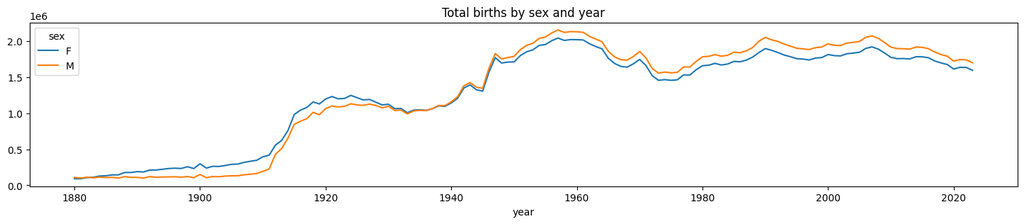

```python
df.pivot_table(values='births', index=['year'], columns=['sex'], aggfunc='sum').plot(
    title='Total births by sex and year');
```

```python
df.pivot_table(values='births', index=['year'], columns=['sex'], aggfunc='sum')
```

| sex year | F | M |
| --- | --- | --- |
| 1880 | 90994 | 110490 |
| 1881 | 91953 | 100735 |
| 1882 | 107847 | 113686 |
| 1883 | 112320 | 104625 |
| 1884 | 129019 | 114442 |
| ... | ... | ... |
| 2019 | 1676568 | 1792223 |
| 2020 | 1614196 | 1723649 |
| 2021 | 1638188 | 1746499 |
| 2022 | 1636657 | 1741954 |
| 2023 | 1596022 | 1701224 |

144 rows × 2 columns

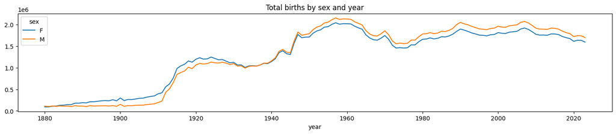

```python
df.pivot_table(values='births', index=['year'], columns=['sex'], aggfunc='sum').plot(
    title='Total births by sex and year');
```

```python
df.pivot_table(values='births', index=['year'], columns=['sex'], aggfunc='sum').tail(1)
```

| sex year | F | M |
| --- | --- | --- |
| 2023 | 1596022 | 1701224 |

```python
df.pivot_table(values='births', index=['year'], columns=['sex'], aggfunc='sum').tail(1)['M'].item()
```

```
1701224
```

```python
df.pivot_table(values='births', index=['year'], columns=['sex'], aggfunc='sum').tail(1)['F'].item()
```

```
1596022
```

```python
df[df.year == 2023]['births'].sum()
```

```
3297246
```

```python
a = df.pivot_table(values='births', index=['year'], columns=['sex'], aggfunc='sum').tail(1)['M'].item()
b = df.pivot_table(values='births', index=['year'], columns=['sex'], aggfunc='sum').tail(1)['F'].item()
c = df[df.year == 2023]['births'].sum()
```

```python
a, b, c
```

```
(1701224, 1596022, 3297246)
```

```python
a + b == c
```

```
True
```

```python
df[(df.year == 2023) & (df.sex == 'M')]['births'].sum()
```

```
1701224
```

```python
df[(df.year == 2023) & (df.sex == 'F')]['births'].sum()
```

```
1596022
```

**Q5** What was the number of births over the entire period?

```python
df['births'].sum()
```

```
368636238
```

```python
df[df.sex == 'M']['births'].sum()
```

```
186337032
```

```python
df[df.sex == 'F']['births'].sum()
```

```
182299206
```

```python
df[df.sex == 'M']['births'].sum() + df[df.sex == 'F']['births'].sum() == df['births'].sum()
```

```
True
```

```python
df['births'].sum()
```

```
368636238
```

**Q6** What was the number of different boy and girl names over the entire period?

```python
df[df.sex == 'M']['name'].nunique()
```

```
44261
```

```python
df[df.sex == 'F']['name'].nunique()
```

```
70903
```

```python
df[df.sex == 'M']['name'].nunique() + df[df.sex == 'F']['name'].nunique()
```

```
115164
```

```python
df['name'].nunique()
```

```
103564
```

```python
a = df[df.sex == 'M']['name'].nunique()
b = df[df.sex == 'F']['name'].nunique()
c = df['name'].nunique()
```

```python
a + b == c
```

```
False
```

```python
df[df.sex == 'M']['name'].nunique(), df[df.sex == 'F']['name'].nunique()
```

```
(44261, 70903)
```

**Q7** How many different names appeared in the years 1880 and 2023?

```python
df[df.year == 1880]['name'].nunique()
```

```
1889
```

```python
df[df.year == 2023]['name'].nunique()
```

```
28945
```

### Boys and girls

We can divide the data into two data frames: one for boys and one for girls. Moreover, we can extract a subset of the data to facilitate further analysis.

```python
boys = df.loc[df.sex == 'M'].reset_index(drop=True)
girls = df.loc[df.sex == 'F'].reset_index(drop=True)
```

```python
boys.head()
```

|  | name | sex | births | year |
| --- | --- | --- | --- | --- |
| 0 | John | M | 9655 | 1880 |
| 1 | William | M | 9532 | 1880 |
| 2 | James | M | 5927 | 1880 |
| 3 | Charles | M | 5348 | 1880 |
| 4 | George | M | 5126 | 1880 |

```python
girls.tail()
```

|  | name | sex | births | year |
| --- | --- | --- | --- | --- |
| 1245554 | Zuni | F | 5 | 2023 |
| 1245555 | Zura | F | 5 | 2023 |
| 1245556 | Zurisadai | F | 5 | 2023 |
| 1245557 | Zyairah | F | 5 | 2023 |
| 1245558 | Zyn | F | 5 | 2023 |

### Names in time

We will use [advanced indexing](https://pandas.pydata.org/pandas-docs/stable/user_guide/advanced.html) to set the DataFrame index (row labels) using one or more existing columns.

```python
boys = boys.set_index(['name', 'year'])
girls = girls.set_index(['name', 'year'])
```

```python
boys
```

| name | year | sex | births |
| --- | --- | --- | --- |
| John | 1880 | M | 9655 |
| William | 1880 | M | 9532 |
| James | 1880 | M | 5927 |
| Charles | 1880 | M | 5348 |
| George | 1880 | M | 5126 |
| ... | ... | ... | ... |
| Zyell | 2023 | M | 5 |
| Zyen | 2023 | M | 5 |
| Zymirr | 2023 | M | 5 |
| Zyquan | 2023 | M | 5 |
| Zyrin | 2023 | M | 5 |

871660 rows × 2 columns

```python
john = boys.loc['John']
```

```python
john.shape
```

```
(144, 2)
```

```python
john.head()
```

| year | sex | births |
| --- | --- | --- |
| 1880 | M | 9655 |
| 1881 | M | 8768 |
| 1882 | M | 9557 |
| 1883 | M | 8894 |
| 1884 | M | 9388 |

```python
john.tail()
```

| year | sex | births |
| --- | --- | --- |
| 2019 | M | 8852 |
| 2020 | M | 8259 |
| 2021 | M | 8177 |
| 2022 | M | 7978 |
| 2023 | M | 7750 |

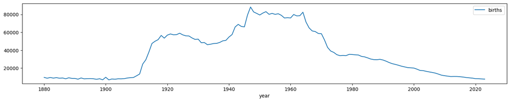

```python
john.plot();
```

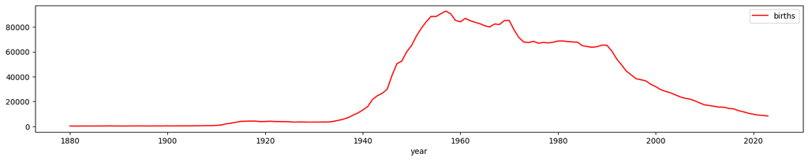

```python
boys.loc['Michael']['births'].plot(color='r', legend=True);
```

Let's see how popular were particular names in time. Can you guess who is who? :)

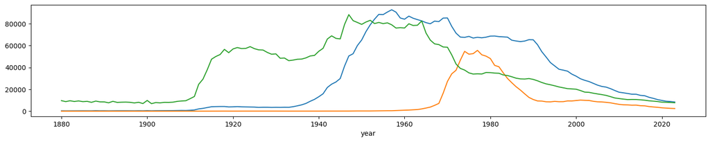

```python
fig, ax = plt.subplots()
boys.loc['Michael']['births'].plot(ax=ax)
boys.loc['Jason']['births'].plot(ax=ax)
boys.loc['John']['births'].plot(ax=ax);
```

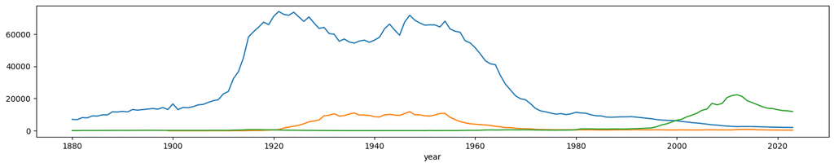

```python
fig, ax = plt.subplots()
girls.loc['Mary']['births'].plot(ax=ax)
girls.loc['Marilyn']['births'].plot(ax=ax)
girls.loc['Sophia']['births'].plot(ax=ax);
```

**Q8** How many girls named Marilyn were born in the years 1960 and 2000?

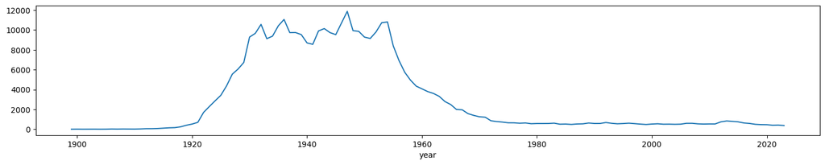

```python
girls.loc['Marilyn']['births'].plot();
```

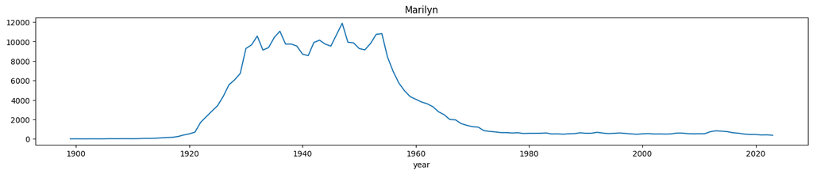

```python
girls.loc['Marilyn']['births'].plot(title='Marilyn');
```

```python
girls.loc['Marilyn']['births']
```

```
year
1899      5
1900     12
1901      6
1903     11
1904      6
       ...
2019    466
2020    457
2021    407
2022    420
2023    377
Name: births, Length: 124, dtype: int64
```

```python
girls.loc['Marilyn']['births'].loc[1960]
```

```
4072
```

```python
girls.loc['Marilyn'].loc[1960]
```

```
sex          F
births    4072
Name: 1960, dtype: object
```

```python
girls.loc['Marilyn'].loc[1960]['births']
```

```
4072
```

```python
girls.loc['Marilyn'].loc[2000]['births']
```

```
524
```

```python
girls.loc['Marilyn'].loc[1960:2000]['births']
```

```
year
1960    4072
1961    3796
1962    3608
1963    3314
1964    2792
        ...
1996     611
1997     567
1998     518
1999     481
2000     524
Name: births, Length: 41, dtype: int64
```

```python
girls.loc['Marilyn'].loc[1960:2000]['births'].mean()
```

```
1140.9512195121952
```

```python
girls.loc['Marilyn'].loc[1960:2000]['births'].sum()
```

```
46779
```

```python
girls.loc['Marilyn'].loc[1960:2000]['births'].max()
```

```
4072
```

```python
girls.loc['Marilyn'].loc[1960]['births'], girls.loc['Marilyn'].loc[2000]['births']
```

```
(4072, 524)
```

**Q9** In which of all years was boy name Jason the most popular?

```python
name = 'Jason'
```

```python
boys.loc[name]
```

| year | sex | births |
| --- | --- | --- |
| 1880 | M | 20 |
| 1881 | M | 22 |
| 1882 | M | 20 |
| 1883 | M | 13 |
| 1884 | M | 25 |
| ... | ... | ... |
| 2019 | M | 3573 |
| 2020 | M | 3102 |
| 2021 | M | 2863 |
| 2022 | M | 2605 |
| 2023 | M | 2456 |

144 rows × 2 columns

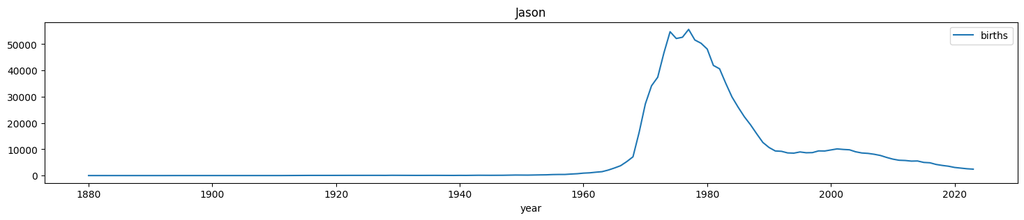

```python
boys.loc[name].plot(title=name);
```

```python
boys.loc[name].min()
```

```
sex       M
births    5
dtype: object
```

```python
boys.loc[name].max()
```

```
sex           M
births    55635
dtype: object
```

```python
boys.loc[name].loc[1972:1980]
```

| year | sex | births |
| --- | --- | --- |
| 1972 | M | 37438 |
| 1973 | M | 46675 |
| 1974 | M | 54754 |
| 1975 | M | 52169 |
| 1976 | M | 52652 |
| 1977 | M | 55635 |
| 1978 | M | 51606 |
| 1979 | M | 50371 |
| 1980 | M | 48166 |

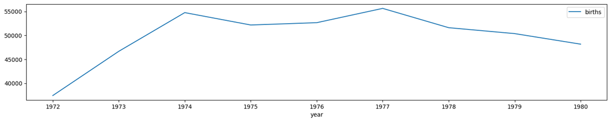

```python
boys.loc[name].loc[1972:1980].plot();
```

```python
boys.loc[name]['births'].max()
```

```
55635
```

```python
boys.loc[name]['births'].idxmax()
```

```
1977
```

**Q10** How many girls were named John? How many boys were named Mary?

```python
df[(df.sex == 'F') & (df.name == 'John')]
```

|  | name | sex | births | year |
| --- | --- | --- | --- | --- |
| 228 | John | F | 46 | 1880 |
| 2312 | John | F | 26 | 1881 |
| 4211 | John | F | 40 | 1882 |
| 6339 | John | F | 40 | 1883 |
| 8453 | John | F | 40 | 1884 |
| ... | ... | ... | ... | ... |
| 1966001 | John | F | 14 | 2019 |
| 2000853 | John | F | 9 | 2020 |
| 2032400 | John | F | 9 | 2021 |
| 2066307 | John | F | 7 | 2022 |
| 2101715 | John | F | 5 | 2023 |

144 rows × 4 columns

```python
df[(df.sex == 'F') & (df.name == 'John')]['births'].sum()
```

```
21734
```

```python
df[(df.sex == 'M') & (df.name == 'Mary')]['births'].sum()
```

```
15172
```

```python
girls.loc['John']['births'].sum()
```

```
21734
```

```python
boys.loc['Mary']['births'].sum()
```

```
15172
```

### Top names

**Q11** For how many names there were more than 50,000 births in one year? List those names.

```python
df[['year', 'name', 'births']].loc[df.births > 50000]
```

|  | year | name | births |
| --- | --- | --- | --- |
| 119717 | 1915 | Mary | 58187 |
| 129074 | 1916 | Mary | 61438 |
| 134235 | 1916 | John | 50043 |
| 138770 | 1917 | Mary | 64280 |
| 144080 | 1917 | John | 51852 |
| ... | ... | ... | ... |
| 1060679 | 1989 | Christopher | 53185 |
| 1085143 | 1990 | Michael | 65313 |
| 1085144 | 1990 | Christopher | 52354 |
| 1110096 | 1991 | Michael | 60803 |
| 1135356 | 1992 | Michael | 54399 |

370 rows × 3 columns

```python
top_names = df[['year', 'name', 'births']].loc[df.births > 50000]
```

```python
top_names
```

|  | year | name | births |
| --- | --- | --- | --- |
| 119717 | 1915 | Mary | 58187 |
| 129074 | 1916 | Mary | 61438 |
| 134235 | 1916 | John | 50043 |
| 138770 | 1917 | Mary | 64280 |
| 144080 | 1917 | John | 51852 |
| ... | ... | ... | ... |
| 1060679 | 1989 | Christopher | 53185 |
| 1085143 | 1990 | Michael | 65313 |
| 1085144 | 1990 | Christopher | 52354 |
| 1110096 | 1991 | Michael | 60803 |
| 1135356 | 1992 | Michael | 54399 |

370 rows × 3 columns

```python
top_names['name'].nunique()
```

```
20
```

```python
top_names['name'].unique()
```

```
array(['Mary', 'John', 'William', 'Robert', 'James', 'Linda', 'Richard',
       'Patricia', 'David', 'Michael', 'Deborah', 'Debra', 'Mark', 'Lisa',
       'Jennifer', 'Christopher', 'Jason', 'Matthew', 'Jessica', 'Ashley'],
      dtype=object)
```

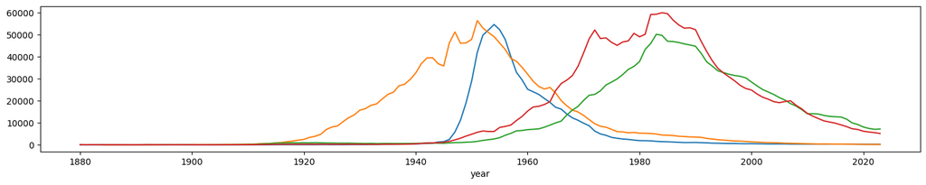

```python
fig, ax = plt.subplots()
girls.loc['Deborah']['births'].plot(ax=ax);
girls.loc['Patricia']['births'].plot(ax=ax);
boys.loc['Matthew']['births'].plot(ax=ax);
boys.loc['Christopher']['births'].plot(ax=ax);
```

```python
top_names['name'].nunique()
```

```
20
```

```python
top_names['name'].unique().tolist()
```

```
['Mary',
 'John',
 'William',
 'Robert',
 'James',
 'Linda',
 'Richard',
 'Patricia',
 'David',
 'Michael',
 'Deborah',
 'Debra',
 'Mark',
 'Lisa',
 'Jennifer',
 'Christopher',
 'Jason',
 'Matthew',
 'Jessica',
 'Ashley']
```

**Q12** How many of those top names were born before and after year 1950?

```python
top_names_list = top_names['name'].unique().tolist()
```

```python
my_names = ['John', 'Michael', 'Jason']
my_names
```

```
['John', 'Michael', 'Jason']
```

```python
df[df['name'].isin(my_names)]
```

|  | name | sex | births | year |
| --- | --- | --- | --- | --- |
| 228 | John | F | 46 | 1880 |
| 942 | John | M | 9655 | 1880 |
| 987 | Michael | M | 354 | 1880 |
| 1327 | Jason | M | 20 | 1880 |
| 2312 | John | F | 26 | 1881 |
| ... | ... | ... | ... | ... |
| 2091608 | Michael | F | 20 | 2023 |
| 2101715 | John | F | 5 | 2023 |
| 2103085 | Michael | M | 8383 | 2023 |
| 2103095 | John | M | 7750 | 2023 |
| 2103216 | Jason | M | 2456 | 2023 |

750 rows × 4 columns

```python
df[df['name'].isin(top_names_list)]
```

|  | name | sex | births | year |
| --- | --- | --- | --- | --- |
| 0 | Mary | F | 7065 | 1880 |
| 228 | John | F | 46 | 1880 |
| 286 | William | F | 30 | 1880 |
| 304 | Linda | F | 27 | 1880 |
| 343 | James | F | 22 | 1880 |
| ... | ... | ... | ... | ... |
| 2103158 | Robert | M | 3807 | 2023 |
| 2103216 | Jason | M | 2456 | 2023 |
| 2103290 | Richard | M | 1638 | 2023 |
| 2103320 | Mark | M | 1386 | 2023 |
| 2106938 | Ashley | M | 28 | 2023 |

4647 rows × 4 columns

```python
df_top = df[df['name'].isin(top_names_list)]
```

```python
df_top.loc[df.year > 1950]
```

|  | name | sex | births | year |
| --- | --- | --- | --- | --- |
| 472253 | Linda | F | 73982 | 1951 |
| 472254 | Mary | F | 65721 | 1951 |
| 472255 | Patricia | F | 56445 | 1951 |
| 472256 | Deborah | F | 42053 | 1951 |
| 472270 | Debra | F | 17065 | 1951 |
| ... | ... | ... | ... | ... |
| 2103158 | Robert | M | 3807 | 2023 |
| 2103216 | Jason | M | 2456 | 2023 |
| 2103290 | Richard | M | 1638 | 2023 |
| 2103320 | Mark | M | 1386 | 2023 |
| 2106938 | Ashley | M | 28 | 2023 |

2673 rows × 4 columns

```python
df_top.loc[df.year > 1950]['births'].sum()
```

```
32771446
```

```python
df_top.loc[df.year < 1950]['births'].sum()
```

```
15653774
```

### The names with the longest history

**Q13** How many names occured every year so far?

```python
# How many different years are there in our data?
count_years = df['year'].nunique()
count_years
```

```
144
```

```python
boys = df.loc[df.sex == 'M'].reset_index(drop=True)
girls = df.loc[df.sex == 'F'].reset_index(drop=True)
```

```python
boys[boys.name == 'Caysey']
```

|  | name | sex | births | year |
| --- | --- | --- | --- | --- |
| 550085 | Caysey | M | 5 | 2000 |

```python
boys[boys.name == 'John']
```

|  | name | sex | births | year |
| --- | --- | --- | --- | --- |
| 0 | John | M | 9655 | 1880 |
| 1058 | John | M | 8768 | 1881 |
| 2054 | John | M | 9557 | 1882 |
| 3153 | John | M | 8894 | 1883 |
| 4183 | John | M | 9388 | 1884 |
| ... | ... | ... | ... | ... |
| 800983 | John | M | 8852 | 2019 |
| 815100 | John | M | 8259 | 2020 |
| 829146 | John | M | 8177 | 2021 |
| 843225 | John | M | 7978 | 2022 |
| 857536 | John | M | 7750 | 2023 |

144 rows × 4 columns

```python
boys['name'].value_counts()
```

```
name
John         144
Elwood       144
Johnnie      144
Jimmie       144
Hugo         144
            ...
Dhananjay      1
Dmitris        1
Durango        1
Eilijah        1
Zymirr         1
Name: count, Length: 44261, dtype: int64
```

```python
boys['name'].value_counts() == count_years
```

```
name
John          True
Elwood        True
Johnnie       True
Jimmie        True
Hugo          True
             ...
Dhananjay    False
Dmitris      False
Durango      False
Eilijah      False
Zymirr       False
Name: count, Length: 44261, dtype: bool
```

```python
all_time_names_boys = boys['name'].value_counts() == count_years
```

```python
type(all_time_names_boys)
```

```
pandas.core.series.Series
```

```python
all_time_names_girls = girls['name'].value_counts() == count_years
```

```python
all_time_names_boys.loc['John']
```

```
True
```

```python
all_time_names_girls.loc['York']
```

```
False
```

```python
all_time_names_boys[all_time_names_boys]
```

```
name
John        True
Elwood      True
Johnnie     True
Jimmie      True
Hugo        True
            ...
Augustus    True
Elias       True
Phillip     True
Edward      True
Henry       True
Name: count, Length: 472, dtype: bool
```

```python
all_time_names_boys[all_time_names_boys].index
```

```
Index(['John', 'Elwood', 'Johnnie', 'Jimmie', 'Hugo', 'Glen', 'Seth', 'Roger',
       'Laurence', 'Fletcher',
       ...
       'Wilson', 'Nicholas', 'Eli', 'Lee', 'Emmett', 'Augustus', 'Elias',
       'Phillip', 'Edward', 'Henry'],
      dtype='object', name='name', length=472)
```

```python
boys_all_years = all_time_names_boys[all_time_names_boys].index.values.tolist()
```

```python
boys_all_years[:10]
```

```
['John',
 'Elwood',
 'Johnnie',
 'Jimmie',
 'Hugo',
 'Glen',
 'Seth',
 'Roger',
 'Laurence',
 'Fletcher']
```

```python
len(boys_all_years)
```

```
472
```

```python
girls_all_years = all_time_names_girls[all_time_names_girls].index.values.tolist()
```

```python
girls_all_years[:10]
```

```
['Mary',
 'Aurelia',
 'Elsa',
 'Chloe',
 'Susanna',
 'Samantha',
 'Ona',
 'Marietta',
 'Lavinia',
 'Kathrine']
```

```python
len(girls_all_years)
```

```
440
```

### Just for fun...

Let's see what pandas is capable to do in just one line of programming code...

**Q14** What was the most popular name, based on the number of births, in the year 2023?

```python
year = 2023
```

```python
# Group the data by 'year' and find the most popular name
most_popular_names = df.loc[df.groupby('year')['births'].idxmax(), ['year', 'name']]
```

```python
# Convert the result to a dictionary for easy lookup
most_popular_names_by_year = most_popular_names.set_index('year')['name'].to_dict()
```

```python
# Retrieve the most popular name for a specific year
most_popular_names_by_year.get(year)
```

```
'Liam'
```

```python
# The most popular boy name in that year
df[df.sex == 'M'].loc[df.loc[df.sex == 'M'].groupby('year')['births'].idxmax(), ['year', 'name']].set_index(
    'year')['name'].to_dict().get(year)
```

```
'Liam'
```

```python
# The most popular girl name in that year
df[df.sex == 'F'].loc[df.loc[df.sex == 'F'].groupby('year')['births'].idxmax(), ['year', 'name']].set_index(
    'year')['name'].to_dict().get(year)
```

```
'Olivia'
```

```python
df[(df.sex=='M') & (df.year == year)].head(3)
```

|  | name | sex | births | year |
| --- | --- | --- | --- | --- |
| 2103070 | Liam | M | 20802 | 2023 |
| 2103071 | Noah | M | 18995 | 2023 |
| 2103072 | Oliver | M | 14741 | 2023 |

```python
df[(df.sex=='F') & (df.year == year)].head(3)
```

|  | name | sex | births | year |
| --- | --- | --- | --- | --- |
| 2085537 | Olivia | F | 15270 | 2023 |
| 2085538 | Emma | F | 13527 | 2023 |
| 2085539 | Charlotte | F | 12596 | 2023 |

```python
# Yes, it can be retrieved using just one line of programming code
df.loc[df.groupby('year')['births'].idxmax(), ['year', 'name']].set_index('year')['name'].to_dict().get(year)
```

```
'Liam'
```

**Q15** Which name had the highest frequency in any single year? Please provide the name, the number of occurrences, and the year.

```python
df['births'].max()
```

```
99693
```

```python
df['births'].idxmax()
```

```
431064
```

```python
df.iloc[df['births'].idxmax()]
```

```
name      Linda
sex           F
births    99693
year       1947
Name: 431064, dtype: object
```

```python
boys = df.loc[df.sex == 'M'].reset_index(drop=True)
girls = df.loc[df.sex == 'F'].reset_index(drop=True)
```

```python
girls = girls.set_index(['name', 'year'])
girls = girls.reset_index()
```

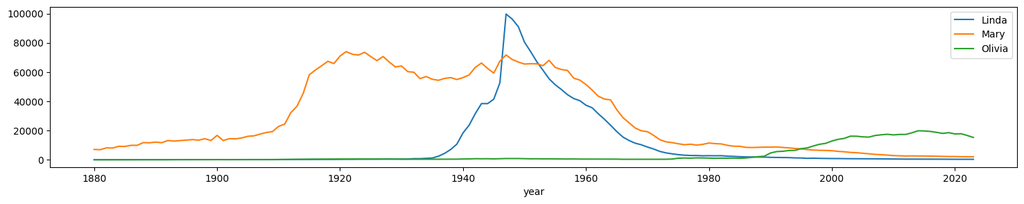

```python
fig, ax = plt.subplots()

girls[girls['name'] == 'Linda'].plot(ax=ax, x='year', y='births', label='Linda');
girls[girls['name'] == 'Mary'].plot(ax=ax, x='year', y='births', label='Mary');
girls[girls['name'] == 'Olivia'].plot(ax=ax, x='year', y='births', label='Olivia');

ax.legend();
```